데이터시각화특강 (전북대학교 2021년 2학기)

# (A2) 데이터시각화 특강 중간고사 대비문제

Nov 5, 2021 • 최규빈 • 3 min read

## Type I. 프로그램 구현능력 평가

### `#`. 자기학번으로 랜덤시드를 만들고 $N(0,1)$, $N(1,1)$인 2개의 정규분포에서 각각 10000개의 관측치를 생성한뒤 saeborn을 이용하여 히스토그램을 그려라.

**힌트**

- 랜덤시드 생성: np.random.seed()를 이용

### `#`. 주어진 자료를 바탕으로 예시와 같은 시각화를 구현하라.

**자료**

```
x=[1,2,3,4]
y=[1,2,4,3]
```

**시각화예시**

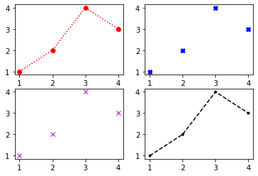

```python
x=[1,2,3,4]
y=[1,2,4,3]
_, axs = plt.subplots(2,2)
axs[0,0].plot(x,y,'o:r')
axs[0,1].plot(x,y,'Xb')
axs[1,0].plot(x,y,'xm')
axs[1,1].plot(x,y,'.--k')
```

## Type II. 개념의 이해 평가

### `#` 아래는 앤스콤의 플랏이다. 옳게 해석한 사람을 모두 고르라

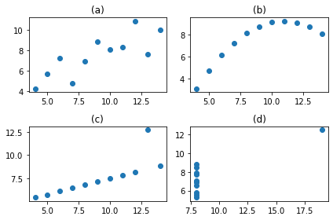

```python
x = [10, 8, 13, 9, 11, 14, 6, 4, 12, 7, 5]
y1 = [8.04, 6.95, 7.58, 8.81, 8.33, 9.96, 7.24, 4.26, 10.84, 4.82, 5.68]
y2 = [9.14, 8.14, 8.74, 8.77, 9.26, 8.10, 6.13, 3.10, 9.13, 7.26, 4.74]
y3 = [7.46, 6.77, 12.74, 7.11, 7.81, 8.84, 6.08, 5.39, 8.15, 6.42, 5.73]
x4 = [8, 8, 8, 8, 8, 8, 8, 19, 8, 8, 8]
y4 = [6.58, 5.76, 7.71, 8.84, 8.47, 7.04, 5.25, 12.50, 5.56, 7.91, 6.89]
fig, axs = plt.subplots(2,2)
axs[0,0].plot(x,y1,'o')
axs[0,0].set_title('(a)')
axs[0,1].plot(x,y2,'o')
axs[0,1].set_title('(b)')
axs[1,0].plot(x,y3,'o')
axs[1,0].set_title('(c)')
axs[1,1].plot(x4,y4,'o')
axs[1,1].set_title('(d)')
fig.tight_layout()
```

(하니) 그림 (a)는 양의 상관계수를 가진다.

(나애리) 그림 (b)는 산점도가 직선이 아니라 곡선의 모양을 띄고 있으므로 상관계수는 0이다.

(홍두깨) 그림 (c)에서 상단의 이상치를 제외하면 상관계수는 1이다.

(고은혜) 그림 (c)와 (d)의 상관계수를 각각 $r_1, r_2$라고 하자. 그리고 (c)와 (d)에서 각각 이상치를 제외한뒤 구한 상관계수를 $\tilde{r}_1, \tilde{r}_2$ 이라고 하자. 그렇다면 $r_1 r_2 < \tilde{r}_1\tilde{r}_2$ 가 성립한다.

### `#`. 아래의 산점도를 보고 옳게 해석한 사람을 모두 고르라.

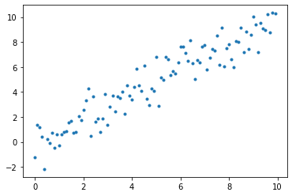

```python
x1=np.arange(0,10,0.1)
y1=x1+np.random.normal(loc=0,scale=1.0,size=len(x1))
plt.plot(x1,y1,'.')
```

(하니) 두 변수는 양의 상관관계에 있어 보인다.

(나애리) 완전한 직선 모양이 되지는 않았으므로 상관계수는 1보다 작다.

(홍두깨) 산점도를 파악하면 $x$가 증가할때 $y$도 증가하므로 $x$가 $y$를 유발하는 원인이라 해석할 수 있다.

(고은혜) $y$를 유지한채 $x$의 값을 모두 2배로 하면 상관계수의 값도 2배가 된다.

## Type III. 자료분석 및 시각화 능력 종합평가

### `#` 아래는 pandas cookbook에 수록된 employee 자료이다.

```python
df=pd.read_csv('https://raw.githubusercontent.com/PacktPublishing/Pandas-Cookbook/master/data/employee.csv')
df
```

|  | UNIQUE_ID | POSITION_TITLE | DEPARTMENT | BASE_SALARY | RACE | EMPLOYMENT_TYPE | GENDER | EMPLOYMENT_STATUS | HIRE_DATE | JOB_DATE |
| --- | --- | --- | --- | --- | --- | --- | --- | --- | --- | --- |
| 0 | 0 | ASSISTANT DIRECTOR (EX LVL) | Municipal Courts Department | 121862.0 | Hispanic/Latino | Full Time | Female | Active | 2006-06-12 | 2012-10-13 |
| 1 | 1 | LIBRARY ASSISTANT | Library | 26125.0 | Hispanic/Latino | Full Time | Female | Active | 2000-07-19 | 2010-09-18 |
| 2 | 2 | POLICE OFFICER | Houston Police Department-HPD | 45279.0 | White | Full Time | Male | Active | 2015-02-03 | 2015-02-03 |
| 3 | 3 | ENGINEER/OPERATOR | Houston Fire Department (HFD) | 63166.0 | White | Full Time | Male | Active | 1982-02-08 | 1991-05-25 |
| 4 | 4 | ELECTRICIAN | General Services Department | 56347.0 | White | Full Time | Male | Active | 1989-06-19 | 1994-10-22 |
| ... | ... | ... | ... | ... | ... | ... | ... | ... | ... | ... |
| 1995 | 1995 | POLICE OFFICER | Houston Police Department-HPD | 43443.0 | White | Full Time | Male | Active | 2014-06-09 | 2015-06-09 |
| 1996 | 1996 | COMMUNICATIONS CAPTAIN | Houston Fire Department (HFD) | 66523.0 | Black or African American | Full Time | Male | Active | 2003-09-02 | 2013-10-06 |
| 1997 | 1997 | POLICE OFFICER | Houston Police Department-HPD | 43443.0 | White | Full Time | Male | Active | 2014-10-13 | 2015-10-13 |
| 1998 | 1998 | POLICE OFFICER | Houston Police Department-HPD | 55461.0 | Asian/Pacific Islander | Full Time | Male | Active | 2009-01-20 | 2011-07-02 |
| 1999 | 1999 | FIRE FIGHTER | Houston Fire Department (HFD) | 51194.0 | Hispanic/Latino | Full Time | Male | Active | 2009-01-12 | 2010-07-12 |

2000 rows × 10 columns

#### (a) 결측치 제거 및 결측치의 갯수 파악하기

df자료에는 결측치가 존재한다. 예를들면 아래에서 9번자료의 RACE는 아무것도 입력되어있지 않아 NaN으로 처리되었다.

```python
df.iloc[8:11,:]
```

|  | UNIQUE_ID | POSITION_TITLE | DEPARTMENT | BASE_SALARY | RACE | EMPLOYMENT_TYPE | GENDER | EMPLOYMENT_STATUS | HIRE_DATE | JOB_DATE |
| --- | --- | --- | --- | --- | --- | --- | --- | --- | --- | --- |
| 8 | 8 | DEPUTY ASSISTANT DIRECTOR (EXECUTIVE LEV | Public Works & Engineering-PWE | 107962.0 | White | Full Time | Male | Active | 1993-11-15 | 2013-01-05 |
| 9 | 9 | AIRPORT OPERATIONS COORDINATOR | Houston Airport System (HAS) | 44616.0 | NaN | Full Time | Male | Active | 2016-03-14 | 2016-03-14 |
| 10 | 10 | FIRE FIGHTER | Houston Fire Department (HFD) | 52644.0 | Hispanic/Latino | Full Time | Male | Active | 2007-05-21 | 2008-11-15 |

아래코드를 실행하여 결측치를 포함한 행을 제거하고 몇개의 결측치가 제거되었는지 답하라.

```
df=df.dropna()
```

#### (b) 여성의 기본급여 평균과 남성의 기본급여 평균을 각각 구하여라. 즉 `GENDER=Male`인 행들의 `BASE_SALARY`의 평균과 `GENDER=Female`인 행들의 `BASE_SALARY`의 평균을 비교하라.

#### (c) 인종과 성별로 자료를 그룹핑하고 기본급여의 평균값 최소값 최대값을 각각 구한뒤 barplot으로 시각화 하라.

**시각화예시**

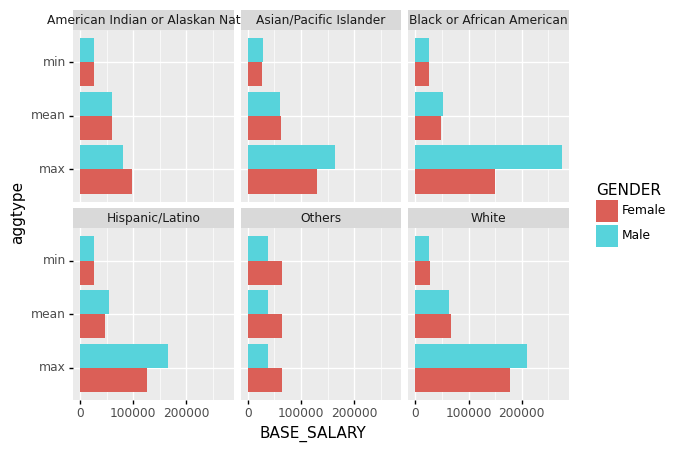

```python
tidy=df.groupby(['RACE','GENDER']).agg({'BASE_SALARY': [np.mean,max,min]}).stack().reset_index().rename(columns={'level_2':'aggtype'})
fig=ggplot(tidy)
bar=geom_bar(aes(x='aggtype',y='BASE_SALARY',fill='GENDER'),stat='identity',position='dodge')
fig+bar+coord_flip()+facet_wrap(facets="RACE")
```